# Econ 104 Project

Mason Lee

2025-03-05

```r
library(tidyverse)
```

```r
library(ggplot2)
library(MASS)
library(dplyr)
library(corrplot)
```

# Section 1

“rm(list = ls())”

## Data

```r
data <- read_csv("data.csv")
sandp <- data[c(1, 2, 6, 8, 9)]

sandp <- rename(sandp, "Interest" = "Long Interest Rate", "Div" = "Real Dividend", "Earn" = "Real Earnings")

sandp$SP500 <- as.numeric(sandp$SP500)
sandp$Earn <- as.numeric(sandp$Earn)
sandp$Interest <- as.numeric(sandp$Interest)
sandp$Div <- as.numeric(sandp$Div)

sandp <- sandp[-c(1830:1833), ]
```

## Question 1: Analysis of Variables

### Histograms

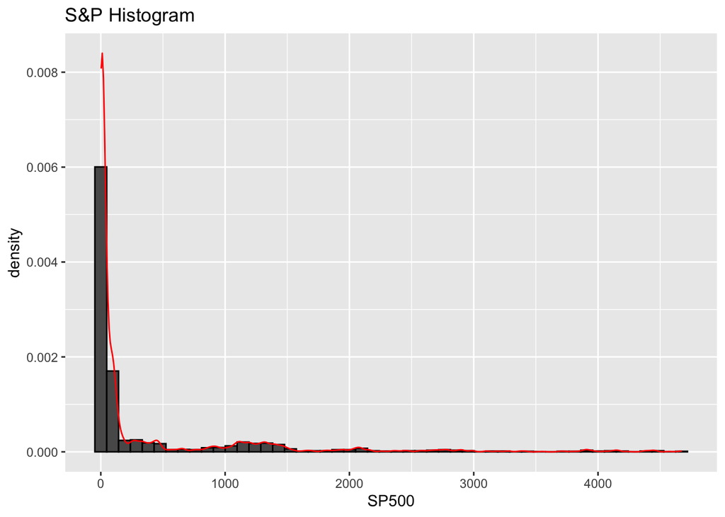

```r
ggplot(data = sandp, aes(x = SP500)) +
  geom_histogram(aes(y = ..density..), bins = 50, color = "black") +
  geom_density(col = "red") +
  ggtitle("S&P Histogram")
```

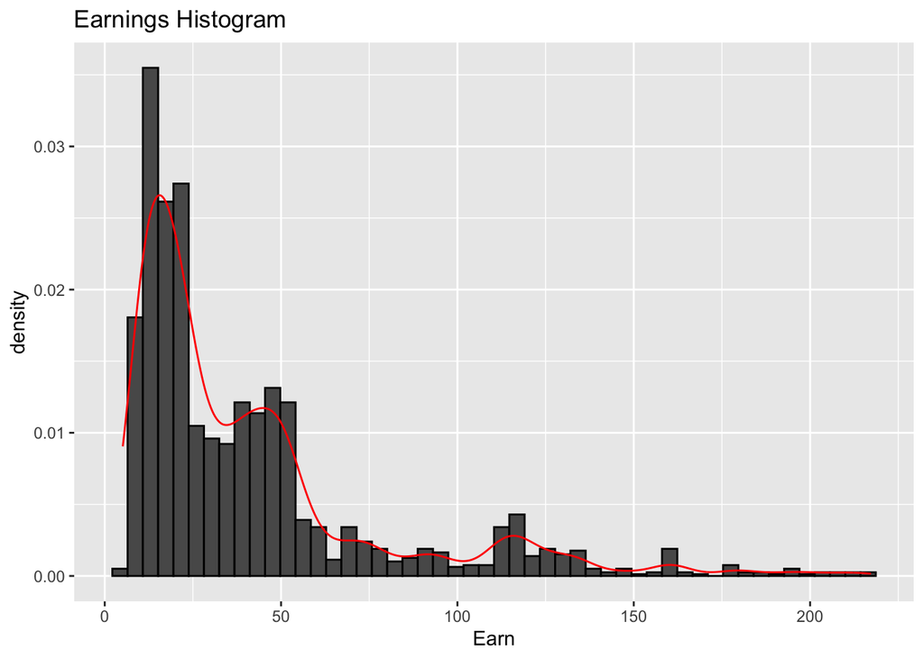

```r
ggplot(data = sandp, aes(x = Earn)) +
  geom_histogram(aes(y = ..density..), bins = 50, color = "black") +
  geom_density(col = "red") +
  ggtitle("Earnings Histogram")
```

The Earnings data is also right skewed, but not as significantly as S&P. This density curve (red line) looks like a multi-tiered log-normal curve. It could also be described as multiple log-normal curves layered on top of each other. This would mean that each earning bracket experiences mirrored but higher earnings, and can definately be used in a model.

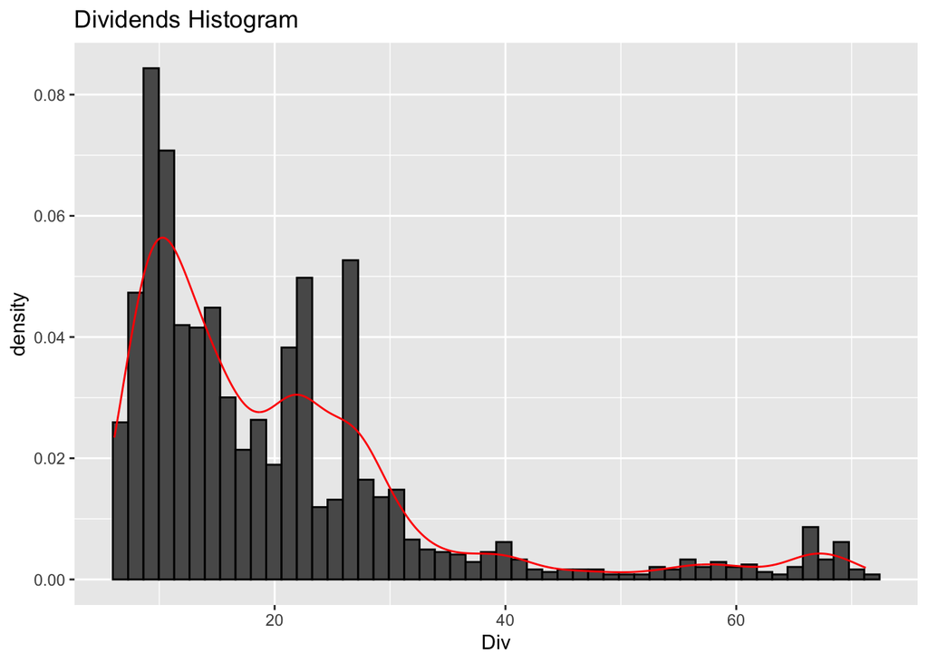

```r
ggplot(data = sandp, aes(x = Div)) +
  geom_histogram(aes(y = ..density..), bins = 50, color = "black") +
  geom_density(col = "red") +
  ggtitle("Dividends Histogram")
```

The Dividends graph is very similar to the Earnings graph, which usually means a high correlation between the two. The density curve is doesn’t quite reach the peaks (outliers or patterns may be present), but we see the same, right skewed pattern with mini peaks all the way down the line.

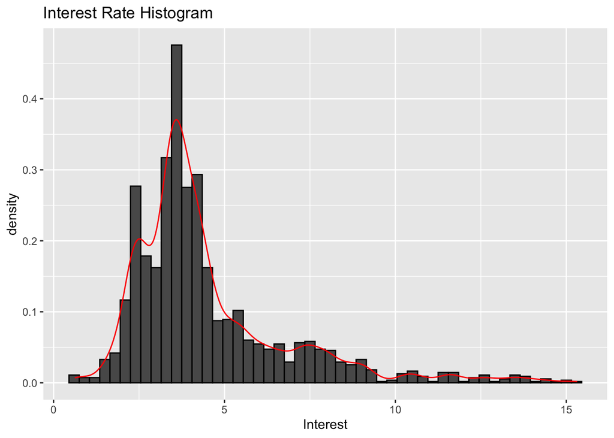

```r
ggplot(data = sandp, aes(x = Interest)) +
  geom_histogram(aes(y = ..density..), bins = 50, color = "black") +
  geom_density(col = "red") +
  ggtitle("Interest Rate Histogram")
```

The Interest rate is supposed to be a number that doesn’t change too quickly, so more central data is expected, and the histogram supports this. There is still a right tail, but the peak is much more normal this time, and almost all of the mini-peaks that we had seen down the right line in previous figures are now gone. For those reasons, Interest should prove to be a good predictor of SP500 and Earnings.

### Correlation Plot

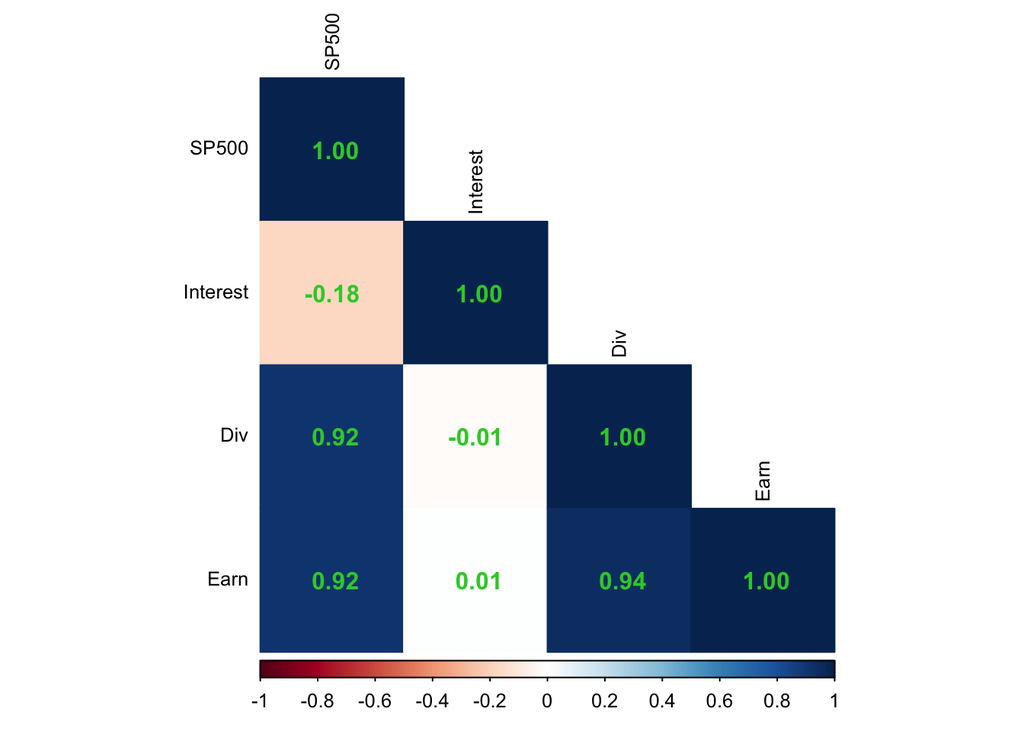

```r
sandp2 <- sandp[, -1]

corr_matrix <- cor(sandp2)

corrplot(corr_matrix, method = "color", type = "lower", addCoef.col = "limegreen", tl.col = "black", tl.cex = 0.8)
```

This Correlation Plot, generated with the corrplot library, provides a quick way to see how closely variables are correlated with each other. The darker the color, the more significant the correlation. I used a new dataset (sandp2) for this problem to eliminate the date variable from the chart.

Each variable is fairly correlated to each other. The least significant correlation is found between the real interest rate and each of the other three variables. It is good to see a high correlation between S&P and Earn, as these are our two y values for the VAR test. We also see a negative corelation between the Interest Rate and the S&P. This is logically correct because when the interest rate is higher, people can make more money leaving their savings in the bank compared to investing, and prices should go down as a result. Interest Rates and Dividend payments have no relationship with each other, but this is because a dividend payment only reflects the stock price and not the rest of the market (same logic for Earn and Interest). Overall, this correlation graph is very promising.

### Boxplot

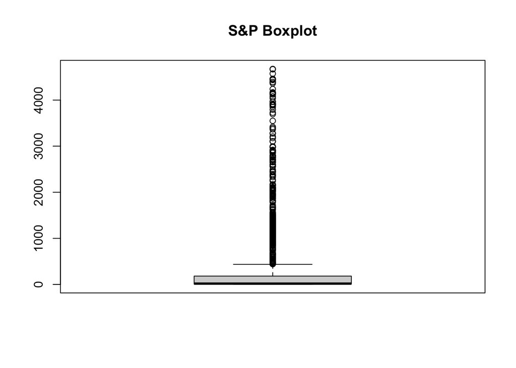

```r
boxplot(sandp$SP500, main = "S&P Boxplot")
```

Due to the nature of the market (increasing exponentially), the median is very low compared to current stock prices. Compounding numbers monthly will always lead to a misleading median, so a boxplot is not a good representation for this variable

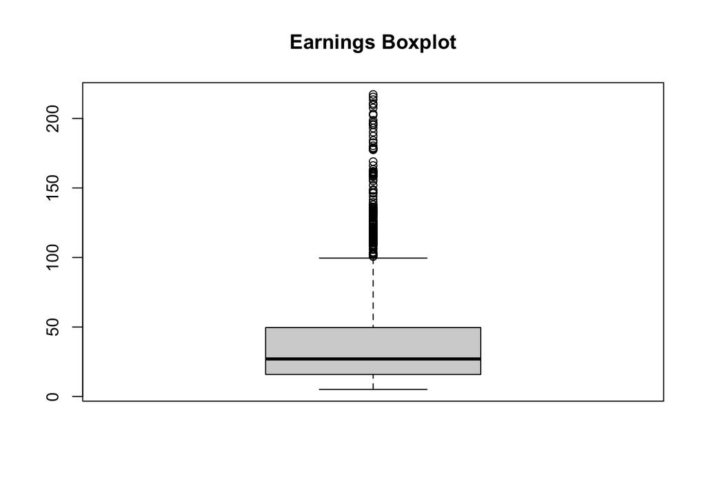

```r
boxplot(sandp$Earn, main = "Earnings Boxplot")
```

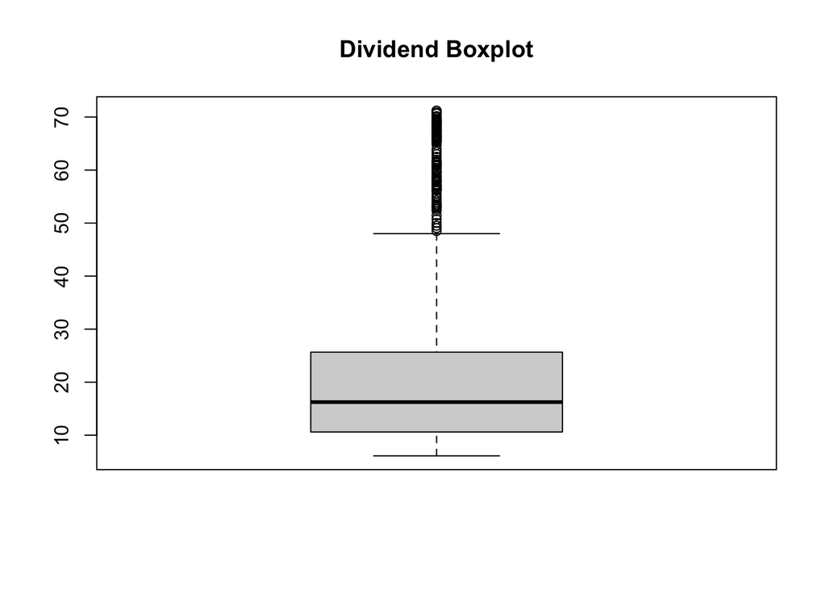

```r
boxplot(sandp$Div, main = "Dividend Boxplot")
```

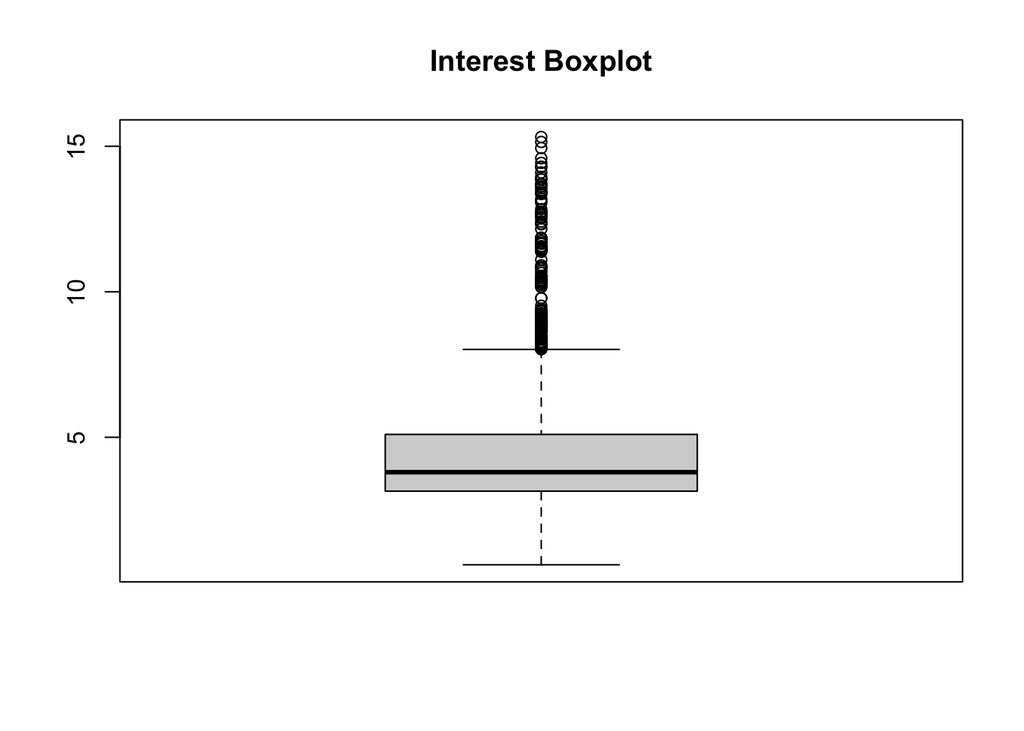

```r
boxplot(sandp$Interest, main = "Interest Boxplot")
```

Interest and the S&P are mostly independent. One can be an indication of the other, but the only way one can influence the other is if the numbers affect someones investment decision. Interest rates tend to be constant around 3%, and that can be seen here. A few outliers (anything about 7.5%) push the median to 4%, but half of the data falls between 3 and 5% historically.

### Scatter Plots

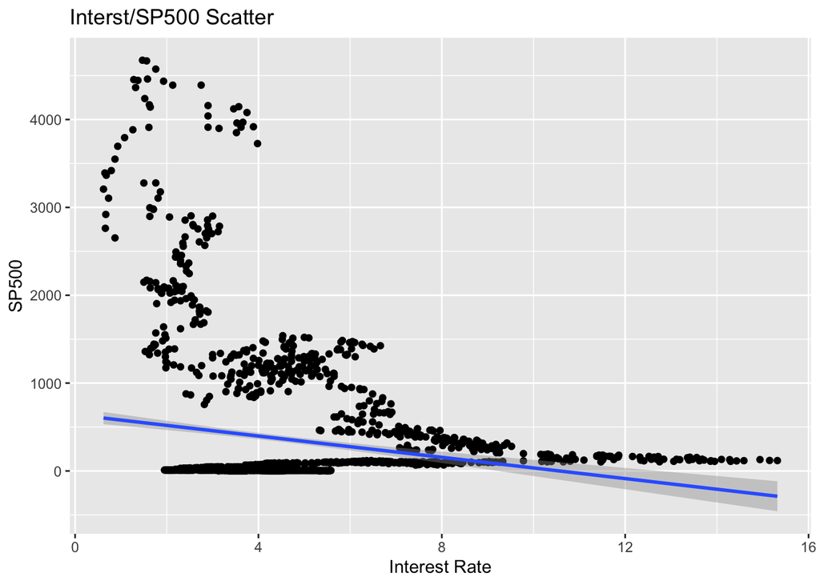

```r
ggplot(data = sandp, aes(x = Interest, y = SP500)) +
  geom_point() +
  geom_smooth(method = "lm") +
  ggtitle("Interst/SP500 Scatter") +
  labs(x = "Interest Rate", y = "SP500")
```

As dictated by our correlation figure, a lower interest rate leads to a higher SP500 figure. The blue line of best fit reflects this negative relationship. The corelation is weak but the pattern is clear.

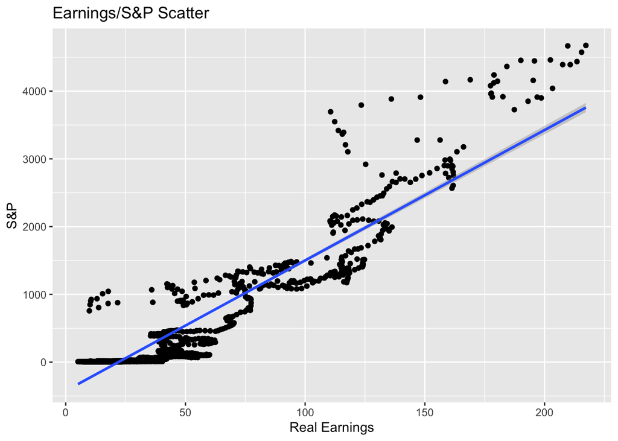

```r
ggplot(data = sandp, aes(x = Earn, y = SP500)) +
  geom_point() +
  geom_smooth(method = "lm") +
  ggtitle("Earnings/S&P Scatter") +
  labs(x = "Real Earnings", y = "S&P")
```

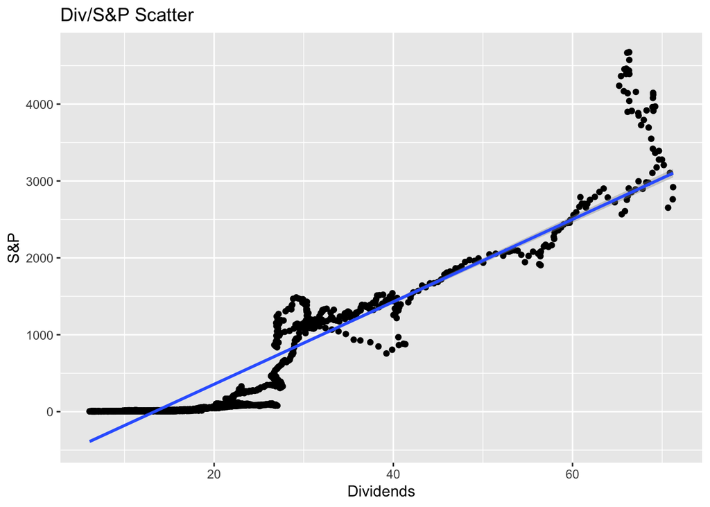

```r
ggplot(data = sandp, aes(x = Div, y = SP500)) +
  geom_point() +
  geom_smooth(method = "lm") +
  ggtitle("Div/S&P Scatter") +
  labs(x = "Dividends", y = "S&P")
```

This graph features a similar pattern to the one directly above, with a sharp rise towards the end. This is because it takes many years to build the curving figure seen snaking up the line of best fit, and the S&P just recently hit 3000+ points. Dividend payments are very constant at these newer levels despite the S&P fluctuating.

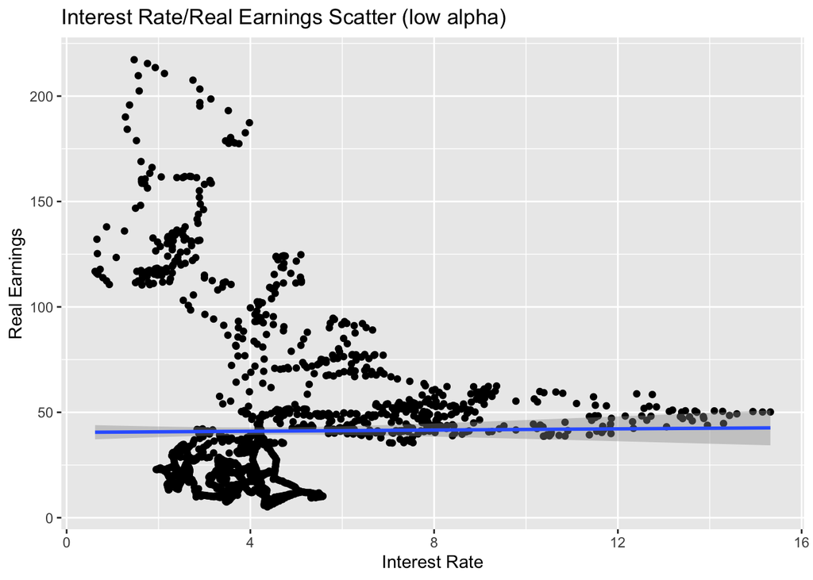

```r
ggplot(data = sandp, aes(x = Interest, y = Earn)) +
  geom_point() +
  geom_smooth(method = "lm") +
  ggtitle("Interest Rate/Real Earnings Scatter (low alpha)") +
  labs(x = "Interest Rate", y = "Real Earnings")
```

There does not seem to be a real pattern between Earnings and the Interest Rate. It seems that earnings are constant at around 50 when the Interest rate is in outlier territory, but when it settles down Earnings seem to fluctuate. My prediction is that this is because of the random walk of stock prices when interest is standard, but more analysis is needed to prove this.

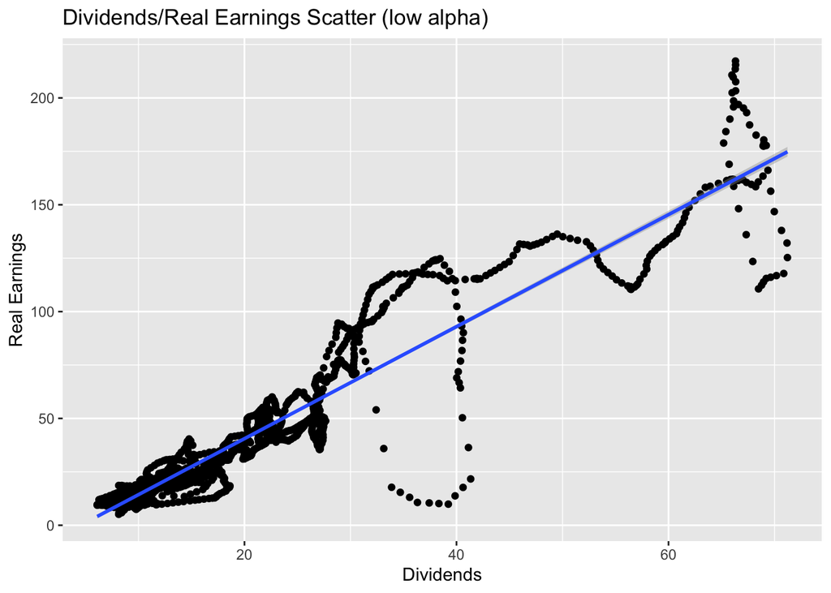

```r
ggplot(data = sandp, aes(x = Div, y = Earn)) +
  geom_point() +
  geom_smooth(method = "lm") +
  ggtitle("Dividends/Real Earnings Scatter (low alpha)") +
  labs(x = "Dividends", y = "Real Earnings")
```

Dividends and Earnings have a very strong, positive corelation. They don’t directly predict each other, but provide useful information. Because of a stocks random walk, we see the upwards snaking pattern, but with more clarity in the more recent, higher paying years.

### 5 Number Summary

The 5 Number Summaries tend to show similar information as the Boxplots. The middle three numbers (1st Quartile, Median, 3rd Quartile), are exactly the same. The first and last numbers are the variables minimum and maximum value.

```r
fivenum(sandp$SP500)
```

```
## [1]    2.730    7.930   18.020  180.900 4674.773
```

```r
fivenum(sandp$CPI)
```

```
## [1] NA NA NA NA NA
```

```r
fivenum(sandp$Div)
```

```
## [1]  6.11 10.61 16.24 25.66 71.22
```

```r
fivenum(sandp$Interest)
```

```
## [1]  0.62  3.15  3.80  5.10 15.32
```

## Question 2: TSDisplay